# Introduction to *serac*

Rosalie Bruel and Pierre Sabatier

Last update: 2021-12-10

The present vignette helps you compute your first age-depth model with *serac*, a R package for ShortlivEd RAdionuclide Chronology of recent sediment cores.

[figure not shown]

# 1 First time user

## 1.1 Setting up the folders

Which folder are your currently working in?

```r
getwd()
```

If you want to work in another folder, change it with setwd(““), e.g.:

```r
setwd("~/myProject/Age depth model")
```

Line below will create the ‘Cores’ folder if it doesn’t exist already

```r
dir.create(file.path(getwd(), 'Cores'), showWarnings = FALSE)
```

Within the ‘Cores’ folder, user needs to create one folder per core.

```r
dir.create(file.path(paste0(getwd(),'/Cores'), 'serac_example_ALO09P12'), showWarnings = FALSE)
```

We are writing in this subfolder an example dataset (Source: <a href:“https://www.sciencedirect.com/science/article/pii/S0033589412000294”>Wilhelm et al., 2012).

Format your own data following this template, or get help with formatting using the serac_input_formatting() function.

```r
?serac_example_ALO09P12
write.table(x = serac_example_ALO09P12, file = paste0(getwd(),'/Cores/serac_example_ALO09P12/serac_example_ALO09P12.txt'),col.names = T, row.names = F,sep="\t")
# Including proxy data for this core too
write.table(x = serac_example_ALO09P12_proxy, file = paste0(getwd(),'/Cores/serac_example_ALO09P12/serac_example_ALO09P12_proxy.txt'),col.names = T, row.names = F,sep="\t")
```

## 1.2 User metadata (optional)

One of our goal with *serac* is to improve reproducibility and data management.  
A first and easy step is to associate the name of the scientist (you!) to each model built. To enter personal data (recommended: name, affiliation, ORCID number and email), tape in the following line in the console, and follow instructions.

```r
user_infos()
```

# 2 Run serac

## 2.1 Minimum arguments

At the minimum, your function will be need the name of the core and the coring year. In the example below, I included the **save_code** argument because Rmarkdown doesn’t save code history the way the code can use it. Unless you’re including a plot in a Rmarkdown, I recommend you do not specify this argument, or turn it to its default, i.e., TRUE. That way, you can go back and see your code.

```r
serac(name="serac_example_ALO09P12",coring_yr=2009,
      save_code=FALSE) #do not include 'save_code' if you're working outside a Rmarkdown document
```

## 2.2 Final model

Several sedimentation hypotheses were tested, and this is what the authors ([Wilhelm *et al*, 2012](https://www.sciencedirect.com/science/article/pii/S0033589412000294)) chose as the best model (type in only the function serac – everything that appears below (“Sediment accumulation rate …”) are model outputs):

```r
model_ALO09P12 <-
  serac(name="serac_example_ALO09P12", coring_yr=2009, model=c("CFCS"),
      plotphoto=FALSE, minphoto=c(0), maxphoto=c(210),
      plot_Pb=T, plot_Am=T, plot_Cs=T, Cher=c(30,40), Hemisphere=c("NH"), NWT=c(51,61),
      sedchange=c(75.5),
      plot_Pb_inst_deposit=T, inst_deposit=c(20,28,100,107,135,142,158,186),
      suppdescriptor=TRUE, descriptor_lab=c("Ca/Fe"),
      historic_d=c(20,28,100,107,135,142,158,186),
      historic_a=c(1994,1920,1886,1868),
      historic_n=c("sept 1994 flood","1920 flood","1886 flood","1868 flood ?"),
      min_yr=c(1750),
      dmax=c(180),
      plotpdf=T, preview=T,
      save_code=FALSE)

 Sediment accumulation rate (CFCS model) 0-75.5mm: SAR= 1.18 mm/yr, R2= 0.93
                          Error:     +/- 0.1 mm/yr

 Sediment accumulation rate (CFCS model) 75.5mm-bottom: SAR= 0.8 mm/yr, R2= 0.923
                          Error:     +/- 0.08 mm/yr
 Approximation of age at change(s) in sedimentation rate:
     Best Age: 1952 (uncertainty: 1947-1957)


 Age approximation of instantaneous deposit(s) from CFCS model:
     The instantaneous deposit at 20-28 mm has an estimated range of: 1991-1994.
     The instantaneous deposit at 100-107 mm has an estimated range of: 1913-1929.
     The instantaneous deposit at 135-142 mm has an estimated range of: 1874-1898.
     The instantaneous deposit at 158-186 mm has an estimated range of: 1852-1880.

 Inventory (Lead): 10287.66 Bq/m2 (+/- 232.9 Bq/m2)
 Inventory (Cesium): 19023.688 Bq/m2 (+/- 149.7 Bq/m2)


 ________________________

 The calculation took 2.5029 secs.
```

If you want to see the preview, change preview=T in the code. Before that, make sure to extend your window in RStudio (large plot!)

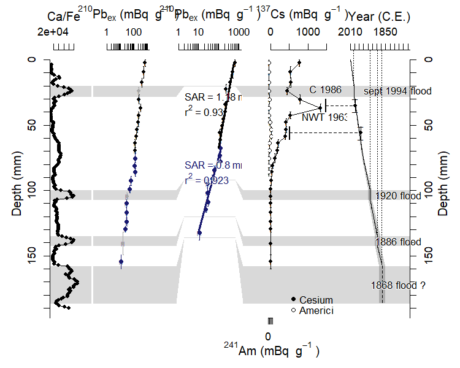

## 2.3 Plot against mass_depth

The plotting options are quite flexible (colors, text size).  
We also offer the possibility to plot the figure against mass depth, using mass accumulation rate instead of sediment accumulation rate for the CFCS model. The code is similar to what we used previously, you just need to add **‘mass_depth = TRUE’** to your function.

```r
model_ALO09P12_mass_depth <-
  serac(name="serac_example_ALO09P12", coring_yr=2009, preview = T,save_code=FALSE, Pbcol = "orange", modelcol = "midnightblue", mycex = .8,
      mass_depth=TRUE)

 Mass accumulation rate (CFCS model): MAR= 0.065 g/cm2/yr, R2= 0.959
                              Error:     +/- 0.003 g/cm2/yr
 Inventory (Lead): 11707.91 Bq/m2 (+/- 253.2 Bq/m2)
 Inventory (Cesium): 21549.328 Bq/m2 (+/- 151.9 Bq/m2)


 ________________________

 The calculation took 0.0884 secs.
```

Note that you can then decide to enter the depth data for the Cesium peaks, instantaneous deposit, and points to ignore in the unit g.cm<sup>-2</sup>. If you want to do that, add the argument **input_depth_mm = FALSE**.

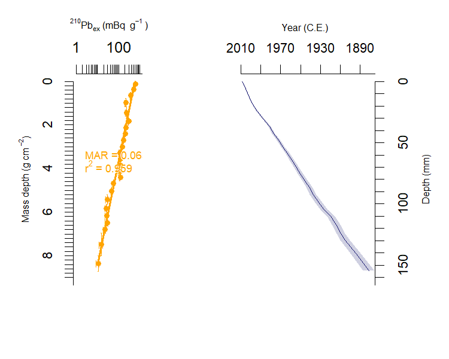

## 2.4 Add varves counting

If varves counting are available, you can display the dates on the age-depth model.

To do so, include in your project’s folder a text file (tab delimited) with two columns: “Age” and “Depth”. Depths must be entered in mm. The file must be named with the name of your sediment core (e.g., “MyCore”), and the append “_varves.txt”.

For example, for the example core *serac_example_ALO09P12*, you would need to include in the serac_example_ALO09P12 folder a file named *serac_example_ALO09P12_varves.txt*. Below is an example of what the file would look like:

| Age | Depth |
| --- | --- |
| 2009 | 0 |
| 2008 | 5 |
| 2007 | 10 |
| 2006 | 15 |
| 2005 | 20 |
| 2004 | 30 |
| 2003 | 35 |
| 2002 | 40 |
| 2001 | 45 |

# 3 Explore outputs

Files with age-depth model and metadata are automatically saved in your working folder. If you assign your function to an object, serac will return a list with the parameters.

```r
mymodel1 <- serac(name="serac_example_ALO09P12", coring_yr=2009, preview = T,save_code=FALSE)

 General message: It seems you already tried this code combination.
 A historic of parameters tested can be looked up in the file
 'serac_model_history_serac_example_ALO09P12.txt' (in the core directory).
 ________________________



 Sediment accumulation rate (CFCS model): SAR= 1.2 mm/yr, R2= 0.96
                          Error:     +/- 0.05 mm/yr
 Inventory (Lead): 11707.91 Bq/m2 (+/- 253.2 Bq/m2)
 Inventory (Cesium): 21549.328 Bq/m2 (+/- 151.9 Bq/m2)


 ________________________

 The calculation took 0.0625 secs.
```

As always when computing a new code, *serac* will check whether you tried the code combination previously. Here, we used the same code than in the previous section, so the code display a message before the outputs.

Note that several objects are accessible from **mymodel1**:  
- data,  
- CFCS sediment accumulation rate,  
- CFCS age-depth model,  
- CFCS age-depth model interpolated,  
- Inventories,  
- plot.  
Depending on the code you chose (and the number of models you visualize), the list of objects increases or decreases.

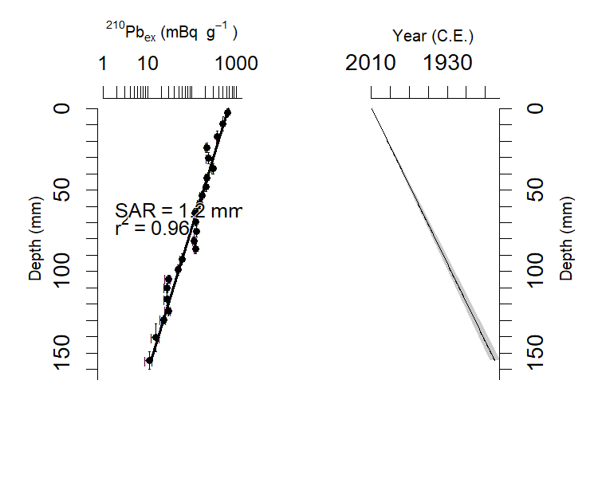

```r
mymodel1$plot
```

```r
# Visualize the input data
knitr::kable(mymodel1$data, format = "markdown")
```

| depth_min | depth_max | density | Pb210ex | Pb210ex_er | Cs137 | Cs137_er | Am241 | Am241_er | Pbex | Pbex_er | Cs | Cs_er | Am | Am_er | depth_top | depth_bottom | depth_avg | thickness | depth_avg_2 | d |
| --- | --- | --- | --- | --- | --- | --- | --- | --- | --- | --- | --- | --- | --- | --- | --- | --- | --- | --- | --- | --- |
| 0 | 5 | 0.47 | 642.0 | 11.0 | 772.0 | 3.0 | 1.00 | 0.51 | 642.0 | 11.0 | 772.0 | 3.0 | 1.00 | 0.51 | 0 | 5 | 2.5 | 5 | 2.5 | 2.5 |
| 5 | 14 | 0.31 | 504.0 | 14.0 | 535.0 | 4.3 | 1.30 | 0.90 | 504.0 | 14.0 | 535.0 | 4.3 | 1.30 | 0.90 | 5 | 14 | 9.5 | 9 | 9.5 | 9.5 |
| 14 | 21 | 0.38 | 371.0 | 7.0 | 540.0 | 2.0 | 1.30 | 0.40 | 371.0 | 7.0 | 540.0 | 2.0 | 1.30 | 0.40 | 14 | 21 | 17.5 | 7 | 17.5 | 17.5 |
| 21 | 27 | 0.66 | 217.0 | 6.0 | 446.0 | 2.0 | 1.60 | 0.40 | 217.0 | 6.0 | 446.0 | 2.0 | 1.60 | 0.40 | 21 | 27 | 24.0 | 6 | 24.0 | 24.0 |
| 27 | 34 | 0.72 | 232.0 | 12.0 | 790.0 | 5.0 | 1.90 | 0.90 | 232.0 | 12.0 | 790.0 | 5.0 | 1.90 | 0.90 | 27 | 34 | 30.5 | 7 | 30.5 | 30.5 |
| 34 | 40 | 0.48 | 305.0 | 11.0 | 1340.0 | 5.0 | 1.20 | 0.90 | 305.0 | 11.0 | 1340.0 | 5.0 | 1.20 | 0.90 | 34 | 40 | 37.0 | 6 | 37.0 | 37.0 |
| 40 | 45 | 0.58 | 219.0 | 10.0 | 530.0 | 3.0 | 1.30 | 0.57 | 219.0 | 10.0 | 530.0 | 3.0 | 1.30 | 0.57 | 40 | 45 | 42.5 | 5 | 42.5 | 42.5 |
| 45 | 51 | 0.48 | 206.0 | 10.0 | 416.0 | 3.3 | 3.20 | 0.70 | 206.0 | 10.0 | 416.0 | 3.3 | 3.20 | 0.70 | 45 | 51 | 48.0 | 6 | 48.0 | 48.0 |
| 51 | 56 | 0.60 | 168.0 | 10.0 | 423.0 | 3.4 | 5.94 | 0.80 | 168.0 | 10.0 | 423.0 | 3.4 | 5.94 | 0.80 | 51 | 56 | 53.5 | 5 | 53.5 | 53.5 |
| 56 | 61 | 0.58 | 147.0 | 8.0 | 395.0 | 4.0 | 5.40 | 0.70 | 147.0 | 8.0 | 395.0 | 4.0 | 5.40 | 0.70 | 56 | 61 | 58.5 | 5 | 58.5 | 58.5 |
| 61 | 67 | 0.45 | 116.0 | 5.0 | 209.0 | 1.6 | 2.30 | 0.40 | 116.0 | 5.0 | 209.0 | 1.6 | 2.30 | 0.40 | 61 | 67 | 64.0 | 6 | 64.0 | 64.0 |
| 67 | 72 | 0.59 | 122.0 | 9.0 | 181.0 | 2.3 | 2.60 | 0.70 | 122.0 | 9.0 | 181.0 | 2.3 | 2.60 | 0.70 | 67 | 72 | 69.5 | 5 | 69.5 | 69.5 |
| 72 | 79 | 0.45 | 125.0 | 8.0 | 117.0 | 1.8 | 1.50 | 0.70 | 125.0 | 8.0 | 117.0 | 1.8 | 1.50 | 0.70 | 72 | 79 | 75.5 | 7 | 75.5 | 75.5 |
| 79 | 83 | 0.63 | 113.0 | 8.0 | 62.4 | 1.3 | 1.35 | 0.60 | 113.0 | 8.0 | 62.4 | 1.3 | 1.35 | 0.60 | 79 | 83 | 81.0 | 4 | 81.0 | 81.0 |
| 83 | 89 | 0.42 | 122.0 | 5.0 | 34.7 | 0.6 | 0.71 | 0.40 | 122.0 | 5.0 | 34.7 | 0.6 | 0.71 | 0.40 | 83 | 89 | 86.0 | 6 | 86.0 | 86.0 |
| 89 | 96 | 0.48 | 58.8 | 3.0 | 16.2 | 0.3 | NA | NA | 58.8 | 3.0 | 16.2 | 0.3 | NA | NA | 89 | 96 | 92.5 | 7 | 92.5 | 92.5 |
| 96 | 102 | 0.57 | 48.4 | 2.0 | 4.5 | 0.1 | NA | NA | 48.4 | 2.0 | 4.5 | 0.1 | NA | NA | 96 | 102 | 99.0 | 6 | 99.0 | 99.0 |
| 102 | 107 | 0.88 | 29.6 | 4.0 | 5.2 | 0.3 | NA | NA | 29.6 | 4.0 | 5.2 | 0.3 | NA | NA | 102 | 107 | 104.5 | 5 | 104.5 | 104.5 |
| 107 | 113 | 0.62 | 26.8 | 3.0 | 6.1 | 0.2 | NA | NA | 26.8 | 3.0 | 6.1 | 0.2 | NA | NA | 107 | 113 | 110.0 | 6 | 110.0 | 110.0 |
| 113 | 121 | 0.41 | 27.4 | 3.0 | 9.4 | 0.2 | NA | NA | 27.4 | 3.0 | 9.4 | 0.2 | NA | NA | 113 | 121 | 117.0 | 8 | 117.0 | 117.0 |
| 121 | 127 | 0.49 | 29.0 | 4.1 | 11.3 | 0.5 | NA | NA | 29.0 | 4.1 | 11.3 | 0.5 | NA | NA | 121 | 127 | 124.0 | 6 | 124.0 | 124.0 |
| 127 | 132 | 0.65 | 23.0 | 3.2 | 12.1 | 0.3 | NA | NA | 23.0 | 3.2 | 12.1 | 0.3 | NA | NA | 127 | 132 | 129.5 | 5 | 129.5 | 129.5 |
| 132 | 149 | 0.62 | 15.4 | 3.0 | 7.7 | 0.3 | NA | NA | 15.4 | 3.0 | 7.7 | 0.3 | NA | NA | 132 | 149 | 140.5 | 17 | 140.5 | 140.5 |
| 149 | 160 | 0.63 | 11.0 | 2.0 | 5.5 | 0.2 | NA | NA | 11.0 | 2.0 | 5.5 | 0.2 | NA | NA | 149 | 160 | 154.5 | 11 | 154.5 | 154.5 |

```r
# Visualize the inventories (if density was in the input data file)
mymodel1$Inventories
              Inventory      min      max
Lead   Bq.m-2  11707.91 11454.75 11961.07
Cesium Bq.m-2  21549.33 21397.45 21701.20
# Save the plot with custom parameters, e.g., Courier font and grey scale without editing default colors.
pdf(paste0(getwd(),"/Cores/serac_example_ALO09P12/serac_example_ALO09P12_custom.pdf"),width = 10, height = 5, family="Courier", colormodel = "grey")
mymodel1$plot
dev.off()
png
  2
```

# 4 Other functions

## 4.1 help_serac()

Another way to read some help.

## 4.2 serac_input_formatting()

If you unsure about the input format of your core (if you have depth in mm, or column names that don’t follow our example), you can use the function *serac_input_formatting(name = “MyCore”)* (MyCore being the name of your core and folder in which the data are located) and follow the steps.

## 4.3 core_metadata()

Enter here a more extensive list of parameters associated to your core. Current list of parameters includes:

- ISGN
- sample date (YYYY-MM-DD)
- latitude (in WGS84)
- longtiude (in WGS84)
- coring method (e.g., gravity corer, piston corer, percussion, etc.)
- subsampling method at the laboratory (e.g., calibrated volumetric sampler, extrusion, etc.)
- instrument type (e.g., alpha spectrometry, well-type germanium detector, P-type germanium detector)
- start of the measurements (YYYY-MM-DD)
- end of the measurements (YYYY-MM-DD)
- any additional comment (e.g., 210Pb background reached, first centimetres lost during coring, etc.)

## 4.4 serac_map()

If you entered GPS coordinates for your core in the previous step, tape in *serac_map()* into your console and view the location of all the systems you entered GPS coordinates for.  
If you enter a vector, e.g., *serac_map(c(“Lake1”, “Lake2”, “Lagoon1”))*, then the map will be generated solely for these systems.

# 5 Citation

If you use *serac*, please cite our paper describing the package:

Bruel, R., Sabatier, P., 2020. serac: A R package for ShortlivEd RAdionuclide chronology of recent sediment cores. Journal of Environmental Radioactivity 225, 106449. https://doi.org/10.1016/j.jenvrad.2020.106449